# NAPED — Portfólio de Ações | Maio 2026

Afya São João del Rei

Portfólio de Ações  
NAPED

Maio de 2026

Registro das iniciativas desenvolvidas pelo Núcleo de Apoio Pedagógico e Experiência Docente

Ação 1Maio 2026

Publicação Científica | Revista Estudos ABMES

Produção de Conhecimento & Avaliação Institucional

O Prof. Dr. Daniel Riani Gotardelo, docente da Afya São João del Rei, publicou artigo na **Revista Estudos** (Ano 34, Nº 46 — Maio de 2026), publicação da Associação Brasileira de Mantenedoras de Ensino Superior (ABMES). A edição, dedicada ao tema *"Guia Completo ENADE & ENAMED 2025: Estratégias e Boas Práticas para a Excelência em Bacharelados, Licenciaturas e CSTs"*, reúne contribuições de especialistas nacionais sobre avaliação da educação superior. A participação do docente evidencia o compromisso do NAPED com a produção de conhecimento e a qualificação dos processos avaliativos institucionais.

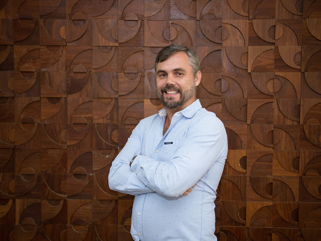

Prof. Dr. Daniel Riani Gotardelo — Docente Afya São João del Rei

[figure not shown]

Revista Estudos ABMES — Ano 34, Nº 46 | Maio 2026

Ação 218 de Maio de 2026

NAPED Day — 7 Anos

Inteligência Artificial e Docência Sustentável

O NAPED Day celebrou sua **7ª edição** com o tema *"Inteligência Artificial e Docência Sustentável"*, reunindo docentes das **37 unidades da Afya** em um evento híbrido de formação e integração. A programação contemplou desde a mobilização prévia — com o **Dia D**, dedicado às inscrições e ao engajamento da equipe —, passando pelas **oficinas formativas** realizadas via Zoom Workplace, até o **encerramento comemorativo** transmitido ao vivo pela plataforma nacional da Afya. As oficinas abordaram temas como protagonismo discente, metodologias ativas e o papel do NAPED na trilha de aprendizagem, reforçando o compromisso institucional com a inovação pedagógica e o desenvolvimento docente contínuo em toda a rede.

Dia D — Mobilização para Inscrições

[figure not shown]

Equipe NAPED — mobilização para inscrições

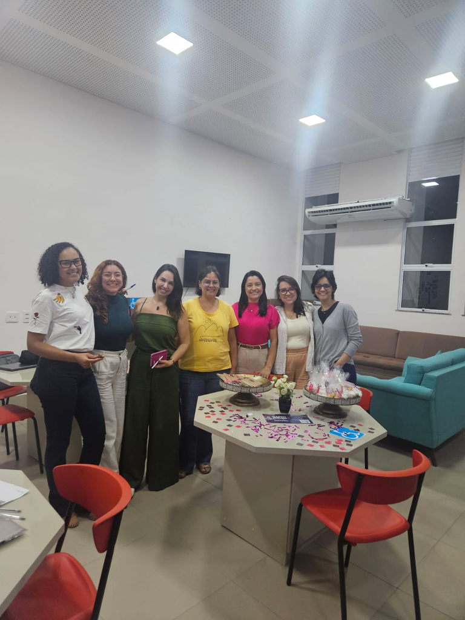

Equipe NAPED — mobilização para inscrições

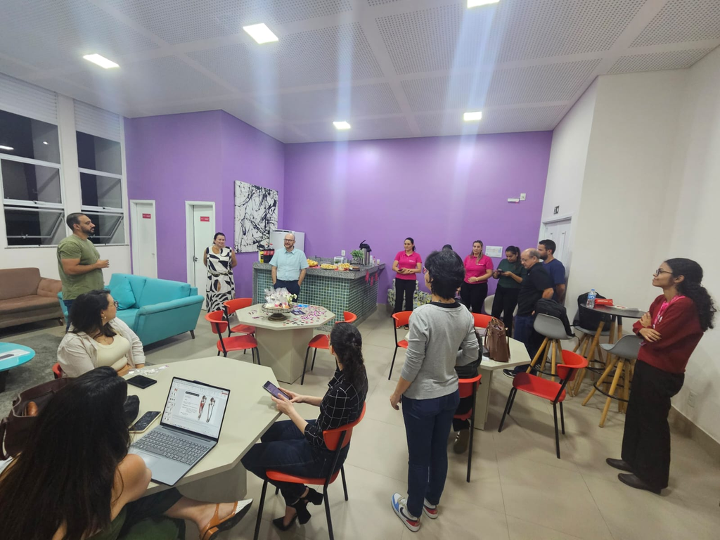

Engajamento e recepção dos docentes

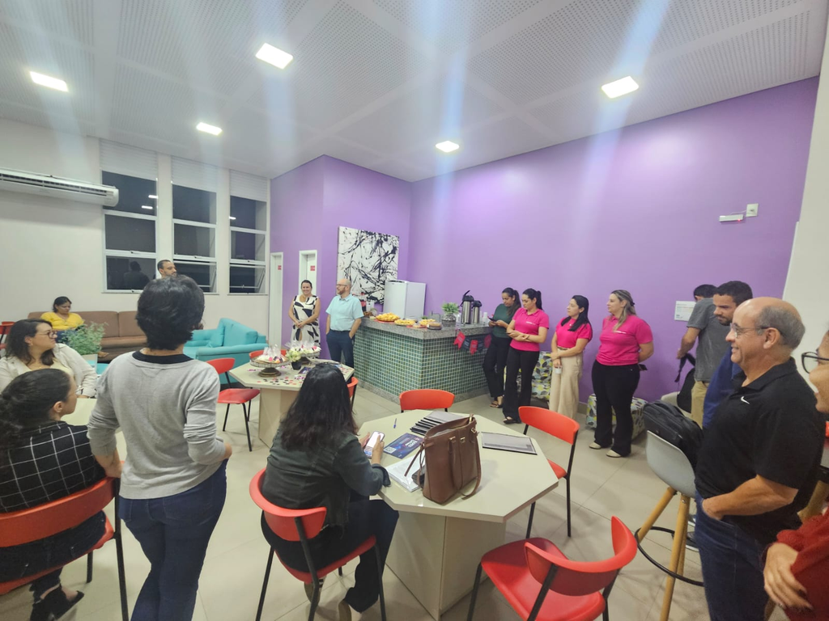

Ambiente NAPED Day

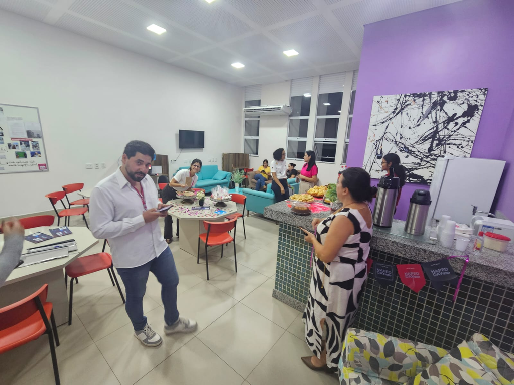

Interação entre docentes

[figure not shown]

Integração da equipe

Abertura do Evento

[figure not shown]

Card oficial — NAPED Day 7 Anos | 18.05.2026

Oficinas Formativas

[figure not shown]

Oficina: O Aluno como Protagonista

[figure not shown]

Oficina: Trilha de Aprendizagem e o papel do NAPED

Encerramento

[figure not shown]

Encerramento — transmissão ao vivo pela plataforma nacional Afya

Ação 3Maio 2026

Reunião Pedagógica | Medicina

Alinhamento Estratégico entre NAPED, Coordenação e Especialistas de Eixo

O NAPED promoveu reunião de alinhamento pedagógico com a coordenação do curso de Medicina e os especialistas de eixo, com foco no desenvolvimento de estratégias para o ciclo básico e o internato. O encontro, realizado de forma remota, teve como eixo central a discussão sobre metodologias de ensino, estrutura de avaliações e trilhas de aprendizagem, incluindo a análise do modelo de **Avaliação do Internato** — que contempla o Teste de Progresso Institucional (TPI), o Mini-Cex adaptado e instrumentos de avaliação de habilidades e atitudes. A iniciativa reforça a atuação do NAPED como articulador entre as dimensões pedagógica e clínica na formação médica.

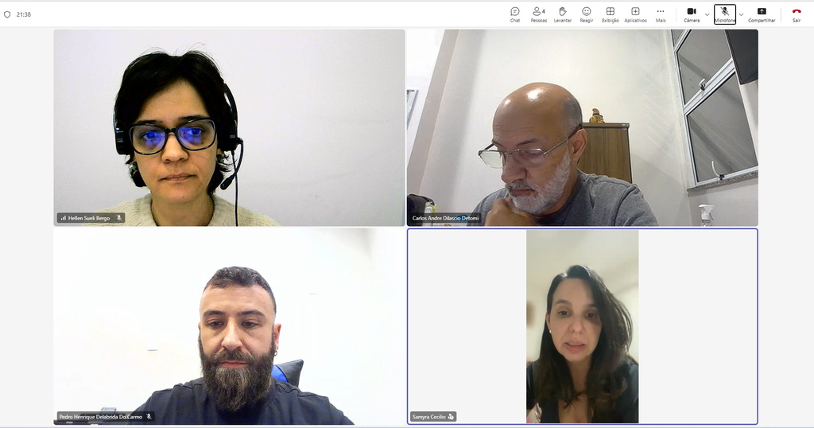

Reunião remota — NAPED, Coordenação de Medicina e Especialistas de Eixo

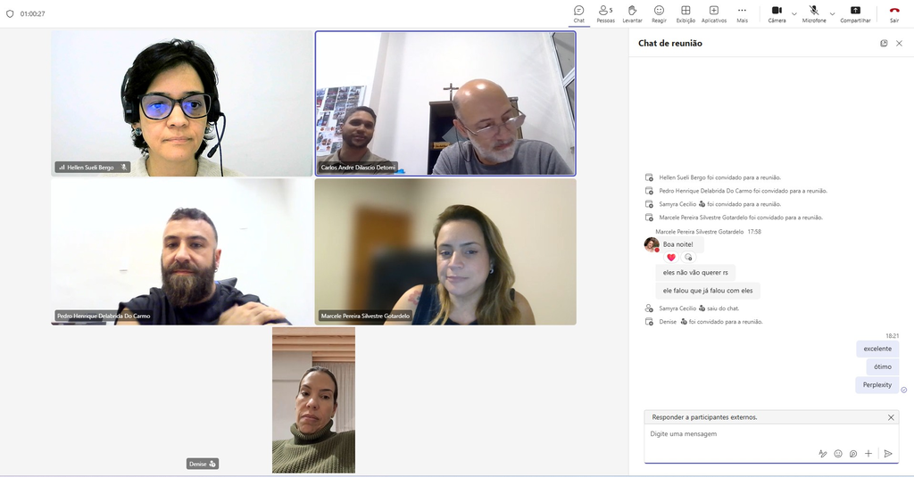

Discussão sobre estratégias pedagógicas no ciclo básico e internato

[figure not shown]

Apresentação: modelo de Avaliação do Internato — TPI, Mini-Cex e instrumentos de habilidades e atitudes

Ação 4Maio 2026

Projeto Mentoria ENAMED

Treinamento de Mentores | Medicina

O NAPED articulou e conduziu o treinamento dos docentes-mentores da Afya São João del Rei para atuação no **Projeto Mentoria ENAMED**, iniciativa da Afya Nacional voltada ao acompanhamento individualizado dos estudantes de Medicina na preparação para o exame. O treinamento abrangeu a apresentação da metodologia nacional do projeto, estruturada em **4 blocos temáticos** ao longo de 8 encontros: Bloco 1 — Trajetória, Pertencimento e Sentido; Bloco 2 — Pressão, Saúde Emocional e Sustentabilidade; Bloco 3 — Maturidade Profissional e Estratégia; e Bloco 4 — Identidade Médica e Projeção Futura. O NAPED garantiu a transposição da proposta nacional para o contexto local, capacitando os mentores para conduzir os encontros com segurança, intencionalidade pedagógica e vínculo com os estudantes.

Treinamento Nacional — Metodologia e Blocos da Mentoria

[figure not shown]

O Mapa da Jornada — Os 4 Blocos da Mentoria

[figure not shown]

Bloco 1: Trajetória, Pertencimento e Sentido da Preparação

Treinamento Local — Mentores Afya São João del Rei

[figure not shown]

Encontro de treinamento com os mentores da unidade

[figure not shown]

Lista de presença — treinamento de mentores

Comunicação e Engajamento dos Mentores

[figure not shown]

Grupo Mentores Medicina 2026 — orientações e materiais

[figure not shown]

Interação no grupo — dúvidas e engajamento dos mentores

[figure not shown]

Compartilhamento de materiais e recursos no grupo

Ação 5Maio 2026

Projeto MOVE

Integração entre Educação Básica e Ensino Superior

O NAPED participou de visita à **Escola Nossa Senhora das Dores** como parte do **Projeto MOVE**, iniciativa institucional da Afya que aproxima professores da educação básica do universo do ensino superior. Por meio de vivências práticas com metodologias ativas, ferramentas digitais e ambientes acadêmicos inovadores, o projeto abre um espaço genuíno de troca, formação e parceria entre os dois níveis de ensino. A visita teve como objetivo convidar a escola a integrar o projeto, fortalecendo os laços entre a Afya São João del Rei e a comunidade educacional local.

[figure not shown]

Visita à Escola Nossa Senhora das Dores — convite para participação no Projeto MOVE

Ação 6Maio 2026

Projeto ENAMED em Foco

Preparação Integrada para o ENAMED | Medicina

O NAPED coordenou um conjunto articulado de ações voltadas à preparação dos estudantes de Medicina para o ENAMED, previsto para setembro. A iniciativa envolveu múltiplas frentes: reunião de alinhamento com a Reitoria e professores médicos, encontros com líderes de turma para escuta e engajamento estudantil, treinamento dos monitores do internato e alinhamento com professores das disciplinas teóricas para organização das aulas. Em paralelo, foram desenvolvidas ações de recuperação de gaps de aprendizagem, com foco nas lacunas identificadas ao longo do semestre. Durante o mês de maio, os estudantes contaram ainda com **encontros diários às 19h** no formato "ENAMED em Foco", abertos a todos os alunos que realizarão o exame, abordando temáticas como Saúde Coletiva, Cirurgia, GO, Saúde Mental e Pediatria — além de sessões de **correção de questões de simulados** ao longo do mês.

Alinhamento Institucional

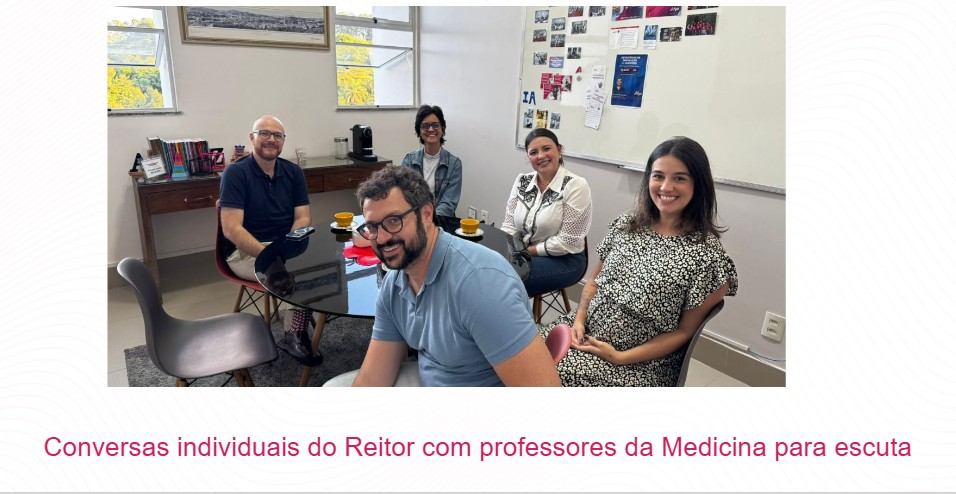

Conversas individuais do Reitor com professores da Medicina — escuta ativa e alinhamento

Escuta e Engajamento Estudantil

[figure not shown]

25/05 — Reunião com líderes de turma: escuta e estabelecimento de parcerias

[figure not shown]

26/05 — Reunião com monitores do internato: escuta e engajamento

Alinhamento Docente e Ações de Recuperação

[figure not shown]

14/05 — Reunião com professores de disciplinas teóricas: organização das aulas do Internato

[figure not shown]

Encontros diários às 19h — ENAMED em Foco: correção de simulados e recuperação de gaps

Ação 7Maio 2026

IX Fórum STHEM Brasil 2026

Premiação e Participação Institucional no Consórcio de Inovação Acadêmica

A Afya São João del Rei conquistou destaque expressivo no **IX Fórum STHEM Brasil 2026**, evento de referência em inovação acadêmica e aprendizagem ativa. Três docentes da instituição tiveram seus trabalhos reconhecidos com o prêmio de **Trabalho Premiado 2026**: os professores **Américo**, **Marcela** e **Eduarda**, cujas produções evidenciam o compromisso da instituição com a inovação pedagógica e a pesquisa aplicada ao ensino superior. A participação institucional no fórum gerou números expressivos: **73 trabalhos submetidos**, com a participação de **90 professores e 17 alunos**, reforçando a cultura de produção acadêmica e o engajamento docente fomentados pelo NAPED ao longo do ano.